# Early Heart Disease Detection

Applied Data Science

Team 9

2024-11-10

## Helper Functions

- prob_to_class: This function translates probability outputs from models into binary class predictions, where any probability above 0.5 is assigned a 1 (disease) and below 0.5 is assigned a 0 (no disease).

```r
# Helper Functions
prob_to_class <- function(ranking_lr,threshold=0.5) {
  # This helper function converts LR probability outputs into 1 and 0 classes
  temp <- ranking_lr > threshold
  temp[temp==TRUE] <- 1
  temp[temp==FALSE] <- 0
  return(as.factor(temp))
}
```

## Data Preparation

- Loading and Structuring Data: The code loads the heart disease dataset from the UCI repository, separates features and target labels, and converts the target to a binary format (1 for disease presence, 0 for absence).
- Combining Data for EDA: The features and labels are combined into a single data frame for easy EDA.

Basic Dataset Information and Summary Statistics:

str(), head(), summary(): These functions reveal the dataset structure, initial rows, and summary statistics.

Missing values are counted using colSums(is.na(data)), and duplicate rows are identified to ensure data integrity.

Numerical summary statistics (mean, standard deviation, min, max) are calculated to understand variable spread and tendency.

```r
# Load heart disease dataset from UCI Machine Learning repository
heart_disease <- fetch_ucirepo(id = 45)
heart_data.X <- heart_disease$data$features  # Features matrix
heart_data.Y <- heart_disease$data$targets   # Target variable

# Recode target to binary: 0 (no disease) and 1 (disease)
labels <- ifelse(as.numeric(heart_data.Y$num) == 0, 0, 1)
features <- as.matrix(heart_data.X)  # Convert features to matrix format
```

### Exploratory Data Analysis

Distribution Analysis:

For numerical features, histograms are plotted to understand each feature’s distribution. Target Variable Distribution: A bar plot illustrates the distribution of the target variable (Class) to check for class imbalance.

Outlier Detection:

Boxplots of each numeric variable display potential outliers, aiding in understanding feature ranges and variance.

Missing Data Visualization:

A missing data map highlights the dataset’s missing values, if any, making it easier to decide on imputation or deletion.

```r
# Combine features and labels into a single data frame for EDA
data <- cbind(features, Class = labels)
data <- as.data.frame(data)

# Basic dataset information and exploratory analysis
cat("Dataset Structure:\n")
```

```
## Dataset Structure:
```

```r
str(data)  # Display structure of dataset
```

```
## 'data.frame':    303 obs. of  14 variables:
##  $ age     : num  63 67 67 37 41 56 62 57 63 53 ...
##  $ sex     : num  1 1 1 1 0 1 0 0 1 1 ...
##  $ cp      : num  1 4 4 3 2 2 4 4 4 4 ...
##  $ trestbps: num  145 160 120 130 130 120 140 120 130 140 ...
##  $ chol    : num  233 286 229 250 204 236 268 354 254 203 ...
##  $ fbs     : num  1 0 0 0 0 0 0 0 0 1 ...
##  $ restecg : num  2 2 2 0 2 0 2 0 2 2 ...
##  $ thalach : num  150 108 129 187 172 178 160 163 147 155 ...
##  $ exang   : num  0 1 1 0 0 0 0 1 0 1 ...
##  $ oldpeak : num  2.3 1.5 2.6 3.5 1.4 0.8 3.6 0.6 1.4 3.1 ...
##  $ slope   : num  3 2 2 3 1 1 3 1 2 3 ...
##  $ ca      : num  0 3 2 0 0 0 2 0 1 0 ...
##  $ thal    : num  6 3 7 3 3 3 3 3 7 7 ...
##  $ Class   : num  0 1 1 0 0 0 1 0 1 1 ...
```

```r
cat("\nFirst few rows:\n")
```

```
##
## First few rows:
```

```r
print(head(data))
```

```
##   age sex cp trestbps chol fbs restecg thalach exang oldpeak slope ca thal
## 1  63   1  1      145  233   1       2     150     0     2.3     3  0    6
## 2  67   1  4      160  286   0       2     108     1     1.5     2  3    3
## 3  67   1  4      120  229   0       2     129     1     2.6     2  2    7
## 4  37   1  3      130  250   0       0     187     0     3.5     3  0    3
## 5  41   0  2      130  204   0       2     172     0     1.4     1  0    3
## 6  56   1  2      120  236   0       0     178     0     0.8     1  0    3
##   Class
## 1     0
## 2     1
## 3     1
## 4     0
## 5     0
## 6     0
```

```r
cat("\nSummary Statistics:\n")
```

```
##
## Summary Statistics:
```

```r
print(summary(data))
```

```
##       age             sex               cp           trestbps
##  Min.   :29.00   Min.   :0.0000   Min.   :1.000   Min.   : 94.0
##  1st Qu.:48.00   1st Qu.:0.0000   1st Qu.:3.000   1st Qu.:120.0
##  Median :56.00   Median :1.0000   Median :3.000   Median :130.0
##  Mean   :54.44   Mean   :0.6799   Mean   :3.158   Mean   :131.7
##  3rd Qu.:61.00   3rd Qu.:1.0000   3rd Qu.:4.000   3rd Qu.:140.0
##  Max.   :77.00   Max.   :1.0000   Max.   :4.000   Max.   :200.0
##
##       chol            fbs            restecg          thalach
##  Min.   :126.0   Min.   :0.0000   Min.   :0.0000   Min.   : 71.0
##  1st Qu.:211.0   1st Qu.:0.0000   1st Qu.:0.0000   1st Qu.:133.5
##  Median :241.0   Median :0.0000   Median :1.0000   Median :153.0
##  Mean   :246.7   Mean   :0.1485   Mean   :0.9901   Mean   :149.6
##  3rd Qu.:275.0   3rd Qu.:0.0000   3rd Qu.:2.0000   3rd Qu.:166.0
##  Max.   :564.0   Max.   :1.0000   Max.   :2.0000   Max.   :202.0
##
##      exang           oldpeak         slope             ca
##  Min.   :0.0000   Min.   :0.00   Min.   :1.000   Min.   :0.0000
##  1st Qu.:0.0000   1st Qu.:0.00   1st Qu.:1.000   1st Qu.:0.0000
##  Median :0.0000   Median :0.80   Median :2.000   Median :0.0000
##  Mean   :0.3267   Mean   :1.04   Mean   :1.601   Mean   :0.6722
##  3rd Qu.:1.0000   3rd Qu.:1.60   3rd Qu.:2.000   3rd Qu.:1.0000
##  Max.   :1.0000   Max.   :6.20   Max.   :3.000   Max.   :3.0000
##                                                  NA's   :4
##       thal           Class
##  Min.   :3.000   Min.   :0.0000
##  1st Qu.:3.000   1st Qu.:0.0000
##  Median :3.000   Median :0.0000
##  Mean   :4.734   Mean   :0.4587
##  3rd Qu.:7.000   3rd Qu.:1.0000
##  Max.   :7.000   Max.   :1.0000
##  NA's   :2
```

```r
cat("\nMissing Values by Column:\n")
```

```
##
## Missing Values by Column:
```

```r
print(colSums(is.na(data)))
```

```
##      age      sex       cp trestbps     chol      fbs  restecg  thalach
##        0        0        0        0        0        0        0        0
##    exang  oldpeak    slope       ca     thal    Class
##        0        0        0        4        2        0
```

```r
cat("\nNumber of Duplicate Rows:\n")
```

```
##
## Number of Duplicate Rows:
```

```r
print(sum(duplicated(data)))
```

```
## [1] 0
```

```r
# Summary statistics for numeric variables
cat("\nSummary Statistics (Numeric Variables):\n")
```

```
##
## Summary Statistics (Numeric Variables):
```

```r
data %>%
  summarise_all(list(mean = ~mean(. , na.rm = TRUE),
                     sd = ~sd(. , na.rm = TRUE),
                     min = ~min(. , na.rm = TRUE),
                     max = ~max(. , na.rm = TRUE)))
```

```
##   age_mean sex_mean  cp_mean trestbps_mean chol_mean  fbs_mean restecg_mean
## 1 54.43894 0.679868 3.158416      131.6898  246.6931 0.1485149     0.990099
##   thalach_mean exang_mean oldpeak_mean slope_mean   ca_mean thal_mean
## 1     149.6073  0.3267327     1.039604    1.60066 0.6722408  4.734219
##   Class_mean   age_sd    sex_sd     cp_sd trestbps_sd  chol_sd    fbs_sd
## 1  0.4587459 9.038662 0.4672988 0.9601256    17.59975 51.77692 0.3561979
##   restecg_sd thalach_sd  exang_sd oldpeak_sd  slope_sd     ca_sd  thal_sd
## 1  0.9949713     22.875 0.4697945   1.161075 0.6162261 0.9374383 1.939706
##    Class_sd age_min sex_min cp_min trestbps_min chol_min fbs_min restecg_min
## 1 0.4991195      29       0      1           94      126       0           0
##   thalach_min exang_min oldpeak_min slope_min ca_min thal_min Class_min age_max
## 1          71         0           0         1      0        3         0      77
##   sex_max cp_max trestbps_max chol_max fbs_max restecg_max thalach_max
## 1       1      4          200      564       1           2         202
##   exang_max oldpeak_max slope_max ca_max thal_max Class_max
## 1         1         6.2         3      3        7         1
```

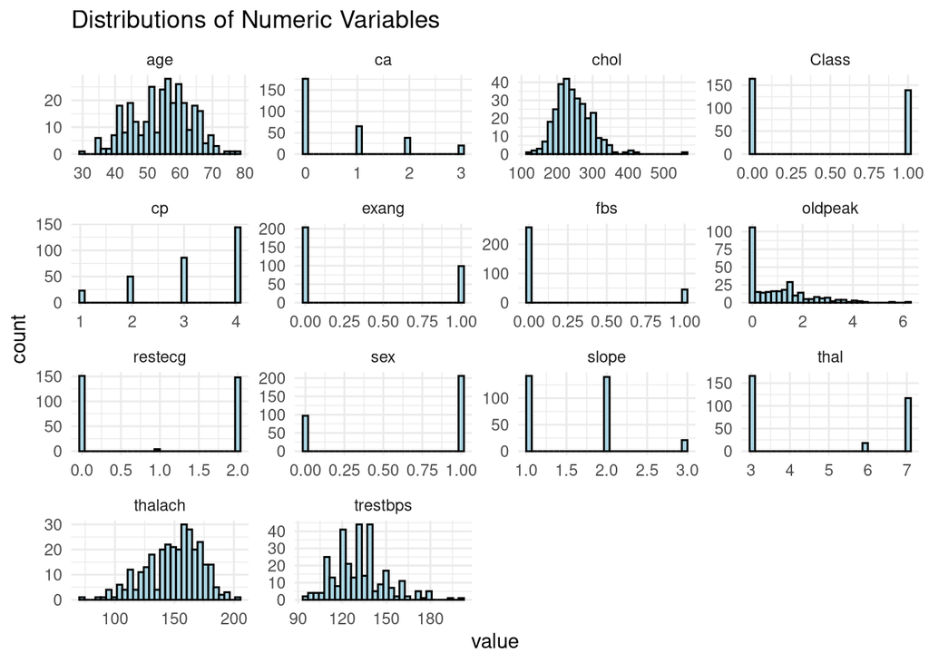

```r
# Distribution of numeric variables
numeric_cols <- sapply(data, is.numeric)
data_num <- data[, numeric_cols]
data_num %>%
  gather() %>%
  ggplot(aes(value)) +
  geom_histogram(bins = 30, color = "black", fill = "lightblue") +
  facet_wrap(~ key, scales = "free") +
  theme_minimal() +
  labs(title = "Distributions of Numeric Variables")
```

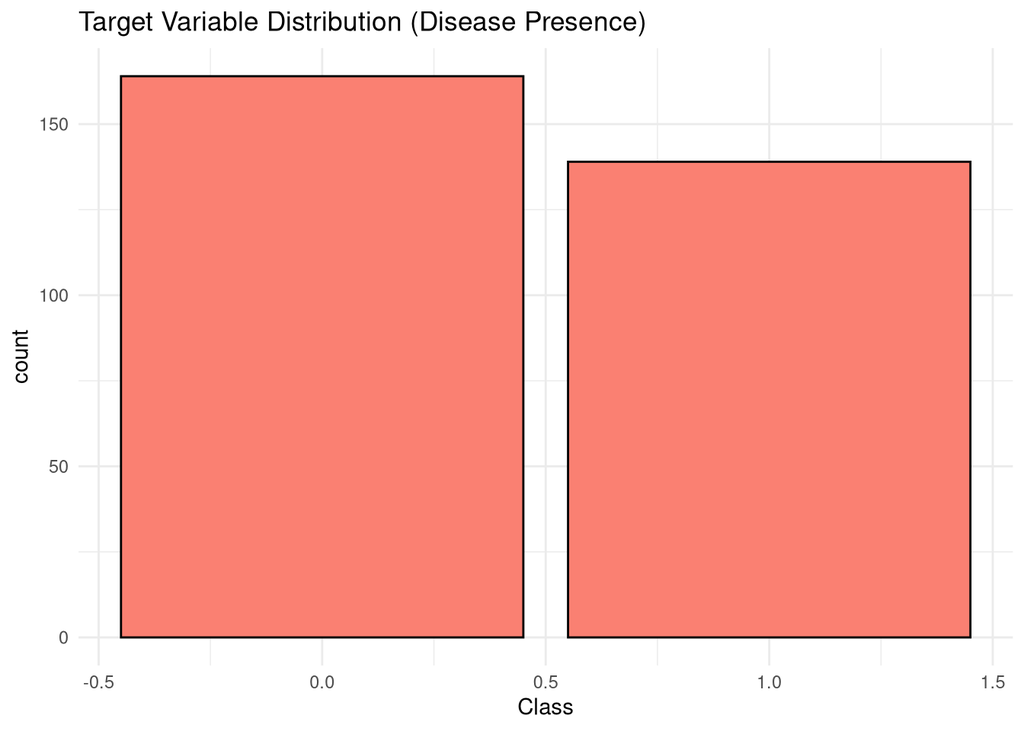

```r
# Distribution of categorical variables
categorical_cols <- sapply(data, is.factor)
data_cat <- data[, categorical_cols]
for (col in names(data_cat)) {
  print(ggplot(data, aes_string(col)) +
          geom_bar(fill = "lightgreen", color = "black") +
          theme_minimal() +
          labs(title = paste("Distribution of", col)))
}

# Target variable distribution
ggplot(data, aes(x = Class)) +
  geom_bar(fill = "salmon", color = "black") +
  theme_minimal() +
  labs(title = "Target Variable Distribution (Disease Presence)")
```

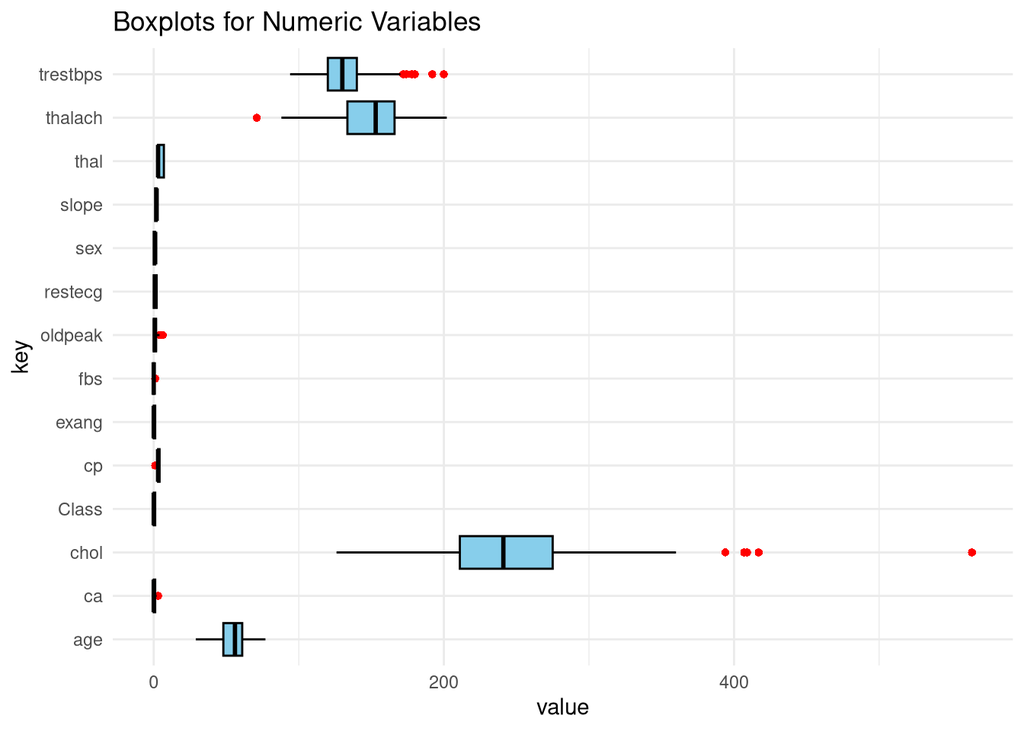

```r
# Outlier detection with boxplots
data_num %>%
  gather() %>%
  ggplot(aes(x = key, y = value)) +
  geom_boxplot(fill = "skyblue", color = "black", outlier.colour = "red", outlier.shape = 16) +
  theme_minimal() +
  labs(title = "Boxplots for Numeric Variables") +
  coord_flip()
```

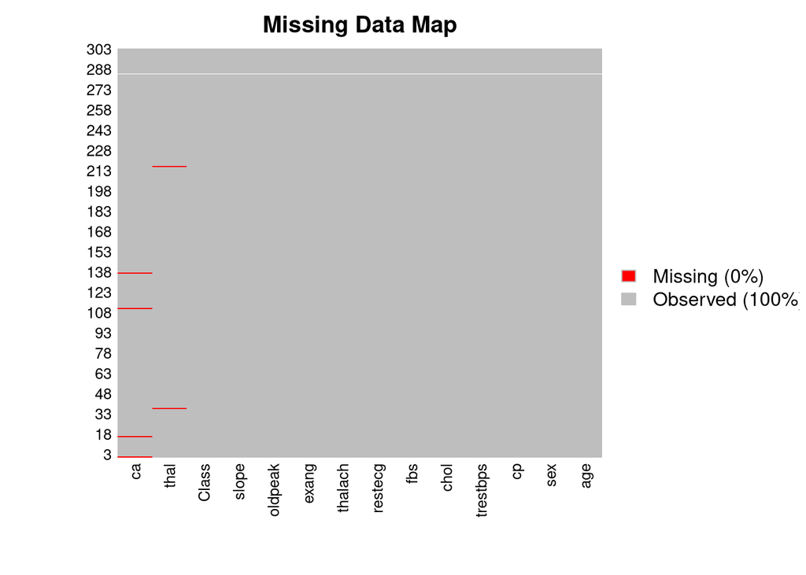

```r
# Visualize missing data
missmap(data, main = "Missing Data Map", col = c("red", "grey"), legend = TRUE)
```

### Train-Test Split and Scaling

First we clean the data by removing rows with NA values.

```r
# Remove rows with missing values from the dataset
na_rows <- which(rowSums(is.na(features)) > 0)
features <- features[-na_rows, ]
labels <- labels[-na_rows]
```

Data Splitting:

The dataset is split into training and testing sets (75%-25% split), ensuring the model is evaluated on unseen data.

Scaling:

Only training data mean and standard deviation are used to scale the training and test sets, preserving data leakage prevention by not incorporating test data statistics into training.

```r
set.seed(123) # For reproducibility

# Perform train and test split
train_in <- sample(1:nrow(features), 0.75 * nrow(features))
train_feat <- features[train_in, ]
train_lab <- labels[train_in]
test_feat <- features[-train_in, ]
test_lab <- labels[-train_in]

# Calculate mean and standard deviation from training data only
train_mean <- apply(train_feat, 2, mean)
train_sd <- apply(train_feat, 2, sd)

# Scale training data
train_feat <- scale(train_feat, center = train_mean, scale = train_sd)

# Scale test data using training data parameters
test_feat <- scale(test_feat, center = train_mean, scale = train_sd)
```

## Model Development

Four models are employed to classify heart disease presence: XGBoost, Lasso Logistic Regression, Random Forest, and Decision Trees.

### Model 1: XG Boost

Data Preparation: xgb.DMatrix format is used for efficient data handling by XGBoost.

Parameter Tuning:

Parameters like eta, max_depth, and gamma are set to optimize model learning, control overfitting, and adjust learning rate and tree depth for better generalization.

Training and Evaluation:

Model is trained for 100 rounds with early stopping after 10 rounds if no improvement in validation loss.

Performance metrics: Confusion matrix, feature importance plot, and AUC score, with ROC curve plotted to visualize trade-offs between sensitivity and specificity.

```r
# Prepare data for XGBoost
dtrain <- xgb.DMatrix(data = train_feat, label = train_lab)
dtest <- xgb.DMatrix(data = test_feat, label = test_lab)

# Define model parameters
param <- list(
  booster = "gbtree",           # Tree-based model
  objective = "binary:logistic",# Binary classification
  eta = 0.1,                    # Learning rate
  max_depth = 3,                # Max tree depth
  gamma = 1,                    # Regularization parameter
  subsample = 0.8,              # Subsample ratio
  colsample_bytree = 0.8,       # Feature sample ratio
  eval_metric = "logloss"       # Evaluation metric
)

# Train XGBoost model
xgb_model <- xgb.train(
  params = param,
  data = dtrain,
  nrounds = 100,                    # Number of boosting rounds
  watchlist = list(train = dtrain, eval = dtest),
  early_stopping_rounds = 10,       # Stop if no improvement
  print_every_n = 10                # Print progress
)
```

```
## Multiple eval metrics are present. Will use eval_logloss for early stopping.
## Will train until eval_logloss hasn't improved in 10 rounds.
##
## Stopping. Best iteration:
```

```r
# Predict probabilities and convert to class labels
pred_probs <- predict(xgb_model, dtest)
pred_labels <- prob_to_class(pred_probs)

# Evaluate model accuracy with confusion matrix
confusion_matrix <- confusionMatrix(reference = as.factor(test_lab), data = as.factor(pred_labels))
print(confusion_matrix)
```

```
## Confusion Matrix and Statistics
##
##           Reference
## Prediction  0  1
##          0 36  8
##          1  5 26
##
##                Accuracy : 0.8267
##                  95% CI : (0.7219, 0.9043)
##     No Information Rate : 0.5467
##     P-Value [Acc > NIR] : 3.126e-07
##
##                   Kappa : 0.6476
##
##  Mcnemar's Test P-Value : 0.5791
##
##             Sensitivity : 0.8780
##             Specificity : 0.7647
##          Pos Pred Value : 0.8182
##          Neg Pred Value : 0.8387
##              Prevalence : 0.5467
##          Detection Rate : 0.4800
##    Detection Prevalence : 0.5867
##       Balanced Accuracy : 0.8214
##
##        'Positive' Class : 0
##
```

```r
# Feature importance
importance_matrix <- xgb.importance(model = xgb_model)
print(importance_matrix)
```

```
##      Feature       Gain       Cover  Frequency
##       <char>      <num>       <num>      <num>
##  1:     thal 0.25172816 0.184253463 0.11052632
##  2:       cp 0.15767490 0.127869980 0.10000000
##  3:  oldpeak 0.15448237 0.167654320 0.13684211
##  4:       ca 0.14263478 0.148339331 0.12105263
##  5:      age 0.08202108 0.101030032 0.14210526
##  6:     chol 0.05614602 0.073451197 0.11052632
##  7:  thalach 0.05474141 0.076847117 0.09473684
##  8: trestbps 0.03117331 0.040227324 0.06315789
##  9:    slope 0.02368516 0.028542699 0.03684211
## 10:      sex 0.02328498 0.025992611 0.04210526
## 11:    exang 0.01161468 0.008625642 0.01052632
## 12:  restecg 0.01081315 0.017166285 0.03157895
```

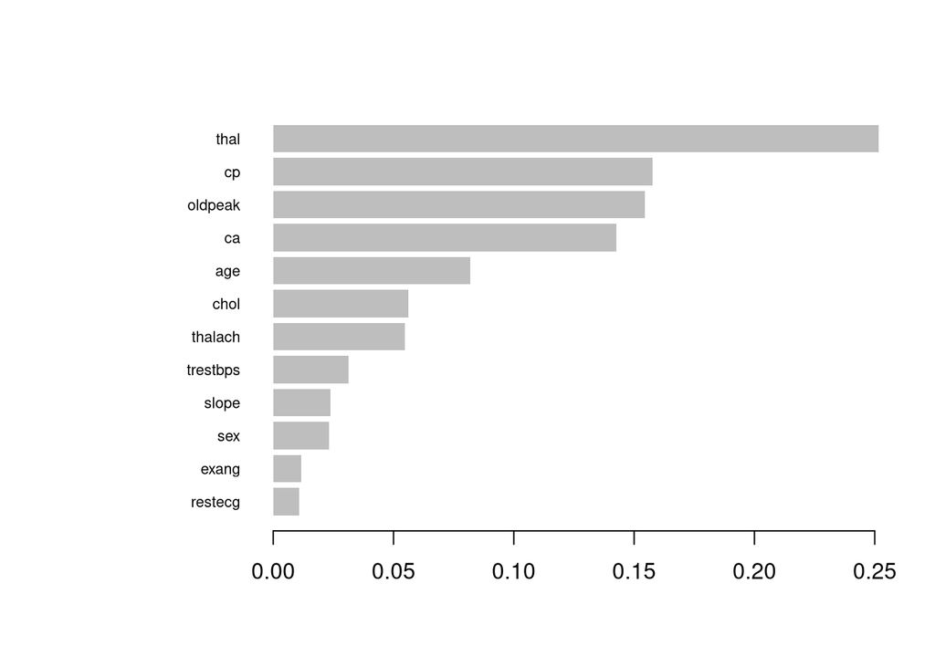

```r
xgb.plot.importance(importance_matrix)
```

```r
# AUC score
# Calculate AUC
roc_xgb <- roc(test_lab, pred_probs)  # Compute ROC curve
auc_xgb <- auc(roc_xgb)             # Calculate AUC
print(paste("AUC:", auc_xgb))
```

```
## [1] "AUC: 0.894906743185079"
```

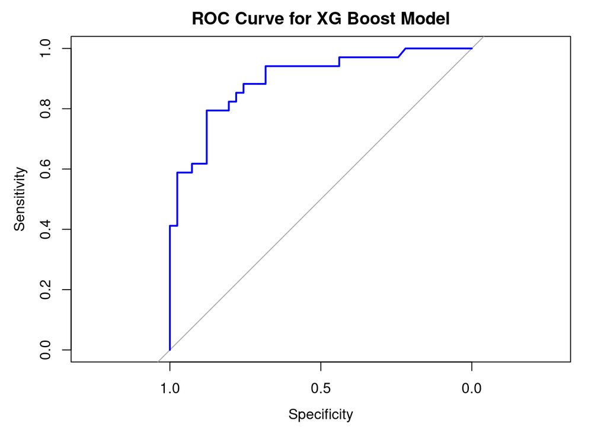

```r
# Plot the ROC curve
plot(roc_xgb, col = "blue", main = "ROC Curve for XG Boost Model")
```

### Model 2: Lasso Logistic Regression

Cross-Validation for Lambda: cv.glmnet with alpha = 1 performs cross-validation to select the optimal lambda value, balancing model fit and regularization.

Final Model Training: With the optimal lambda, the Lasso model is retrained on all features to minimize multicollinearity and overfitting.

Class Prediction: Using prob_to_class, predictions are converted to binary labels, evaluated with a confusion matrix, and ROC and AUC scores are calculated.

```r
#LASSO Logistic Regression using glmnet package

#Train a cross validation model to find optimal lambda value
# using cv.glmnet with alpha =1 and family = "binomial".
cv_model <- cv.glmnet(train_feat, train_lab, family = "binomial", alpha = 1)

#Extracted optimal lambda value for further tuning.
lambda <- cv_model$lambda.min

#Trained final model on all features with the optimal lambda.
lasso <- glmnet(train_feat,train_lab,family = "binomial",
                alpha = 1, lambda = lambda)

#Ranking probabilities given by Lasso on the training data.
ranking_lasso.train <- predict(lasso,train_feat, type="response")

#Ranking probabilities given by Lasso on the validation data.
ranking_lasso.test <- predict(lasso,test_feat, type="response")

#Transformed training probability predictions to class predictions
# using 0.5 threshold
#Used prob_to_class function provided on sample submission.
class_train.lasso <- prob_to_class(ranking_lasso.train)

#Transformed validation probability predictions to class predictions
# using 0.5 threshold
class_test.lasso <- prob_to_class(ranking_lasso.test)

#Confusion matrix for validation data.
cm_test.lasso <- confusionMatrix(reference = as.factor(test_lab),
                                 data = as.factor(class_test.lasso))

#Test prediction results
print(cm_test.lasso)
```

```
## Confusion Matrix and Statistics
##
##           Reference
## Prediction  0  1
##          0 35  7
##          1  6 27
##
##                Accuracy : 0.8267
##                  95% CI : (0.7219, 0.9043)
##     No Information Rate : 0.5467
##     P-Value [Acc > NIR] : 3.126e-07
##
##                   Kappa : 0.6494
##
##  Mcnemar's Test P-Value : 1
##
##             Sensitivity : 0.8537
##             Specificity : 0.7941
##          Pos Pred Value : 0.8333
##          Neg Pred Value : 0.8182
##              Prevalence : 0.5467
##          Detection Rate : 0.4667
##    Detection Prevalence : 0.5600
##       Balanced Accuracy : 0.8239
##
##        'Positive' Class : 0
##
```

```r
lasso_test.roc <- roc(test_lab, as.vector(ranking_lasso.test))
lasso_test.auc <- lasso_test.roc$auc

#AUC Validation Set
lasso_test.auc
```

```
## Area under the curve: 0.8967
```

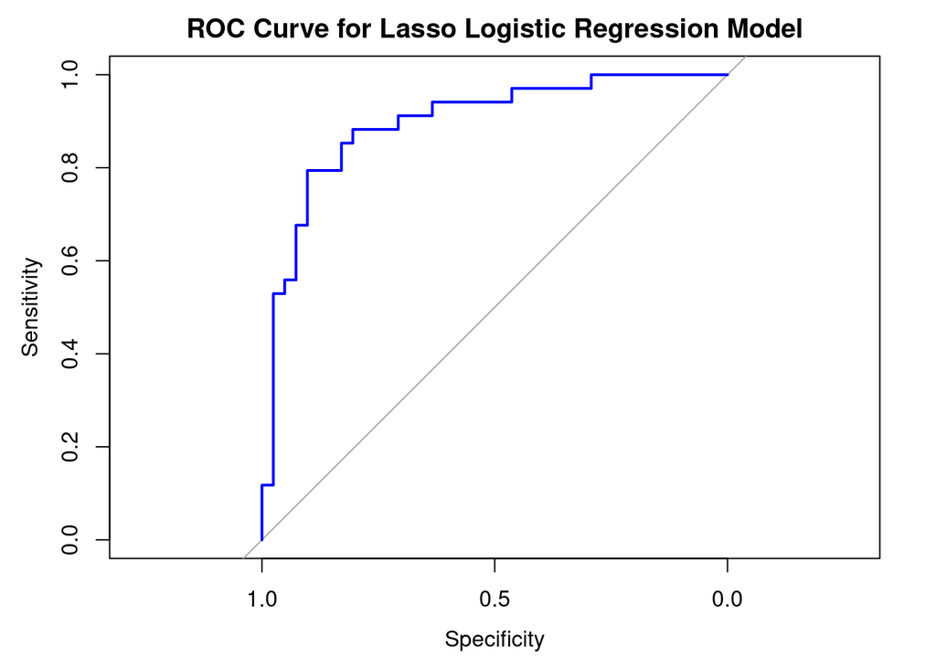

```r
# Plot the ROC curve
plot(lasso_test.roc, col = "blue", main = "ROC Curve for Lasso Logistic Regression Model")
```

### Model 3: Random Forest

Training: The Random Forest model is trained with 100 trees and a mtry value of 2, balancing accuracy and computation time.

Feature Importance: The varImpPlot function visualizes feature importance scores, showing the most influential features in classification.

Performance Evaluation: Predictions are made on test data and assessed via AUC and ROC curve analysis.

```r
# Random Forest
trainData <- data.frame(train_feat,Class = train_lab)
testData <- data.frame(test_feat,Class = test_lab)

rf_model <- randomForest(Class ~ ., data = trainData,
                         ntree = 100, mtry = 2, importance = TRUE)
print(rf_model)
```

```
##
## Call:
##  randomForest(formula = Class ~ ., data = trainData, ntree = 100,      mtry = 2, importance = TRUE)
##                Type of random forest: regression
##                      Number of trees: 100
## No. of variables tried at each split: 2
##
##           Mean of squared residuals: 0.1253966
##                     % Var explained: 49.58
```

```r
# Predict probabilities (second column for class 1 probabilities)
rf_pred <- predict(rf_model, testData)

# Predict and evaluate
predictions <- prob_to_class(rf_pred)
conf_matrix <- confusionMatrix(reference = as.factor(testData$Class),
                               data = predictions)
print(conf_matrix)
```

```
## Confusion Matrix and Statistics
##
##           Reference
## Prediction  0  1
##          0 35  9
##          1  6 25
##
##                Accuracy : 0.8
##                  95% CI : (0.6917, 0.8835)
##     No Information Rate : 0.5467
##     P-Value [Acc > NIR] : 4.117e-06
##
##                   Kappa : 0.5934
##
##  Mcnemar's Test P-Value : 0.6056
##
##             Sensitivity : 0.8537
##             Specificity : 0.7353
##          Pos Pred Value : 0.7955
##          Neg Pred Value : 0.8065
##              Prevalence : 0.5467
##          Detection Rate : 0.4667
##    Detection Prevalence : 0.5867
##       Balanced Accuracy : 0.7945
##
##        'Positive' Class : 0
##
```

```r
# Feature importance
importance(rf_model)
```

```
##             %IncMSE IncNodePurity
## age       3.7253965     3.4452620
## sex       5.5631140     1.5987104
## cp        8.1497901     4.8686974
## trestbps  2.5785407     3.2843576
## chol     -1.4243153     3.8760698
## fbs       0.6374160     0.5994041
## restecg   0.4640741     0.7451365
## thalach   5.8176361     5.9294655
## exang     3.5531271     1.8722876
## oldpeak   8.3660700     6.7449957
## slope     3.2151461     1.7816994
## ca        9.5043599     5.5277335
## thal      8.1050318     6.7431748
```

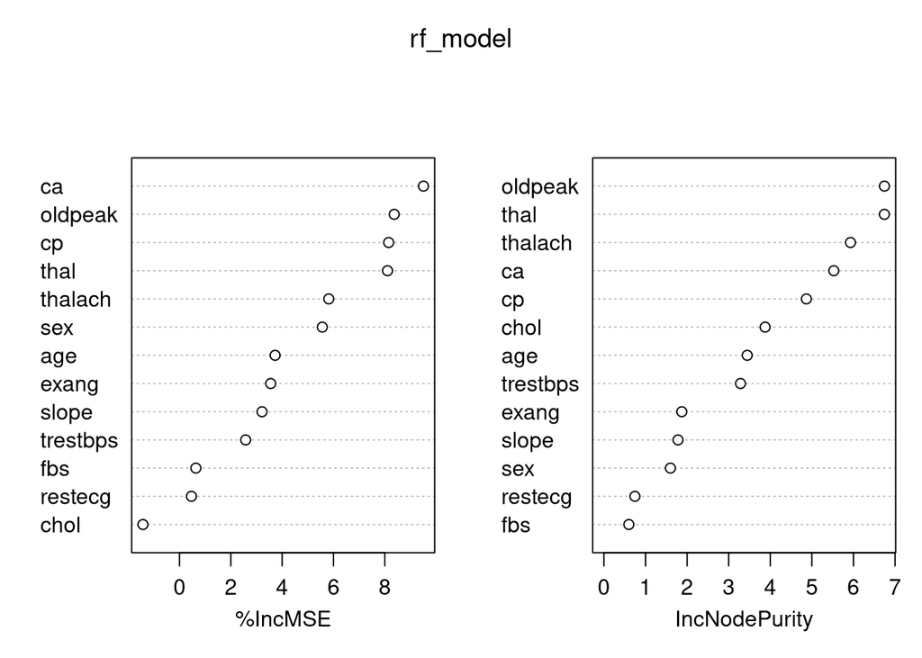

```r
varImpPlot(rf_model)
```

```r
# Calculate AUC
rf_roc <- roc(testData$Class, rf_pred)  # Compute ROC curve
rf_auc <- auc(rf_roc)                   # Calculate AUC
print(paste("AUC:", rf_auc))
```

```
## [1] "AUC: 0.890243902439024"
```

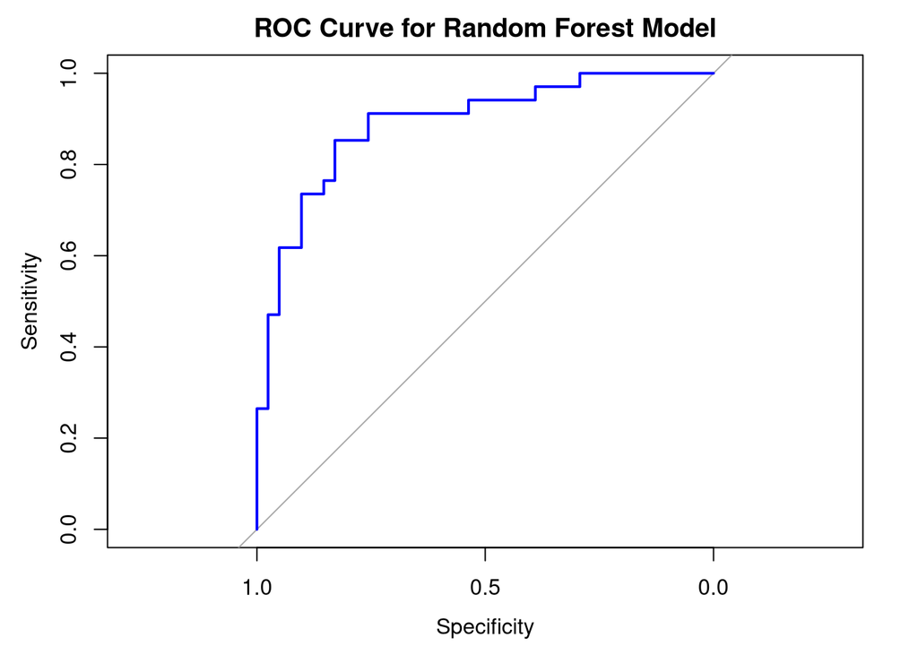

```r
# Plot the ROC curve
plot(rf_roc, col = "blue", main = "ROC Curve for Random Forest Model")
```

### Model 4: Decision Trees

Training: Using the rpart function, the Decision Tree is trained with minsplit = 20 and complexity parameter cp = 0.01.

Tree Visualization: rpart.plot generates a tree plot to help interpret the model’s decision-making process.

Evaluation: Predictions and probability-based ROC/AUC assessments provide a complete view of model performance.

```r
# Data preparation
trainData2 <- trainData
testData2 <- testData
trainData2$Class <- as.factor(trainData2$Class)
testData2$Class <- as.factor(testData2$Class)
# Train the decision tree model
tree_model <- rpart(
  Class ~ .,          # Formula: predicting Class using all other variables
  data = trainData2,  # Training data
  method = "class",   # Method "class" for classification trees
  control = rpart.control(minsplit = 20, cp = 0.01)  # Control parameters
)

# Print the model summary
print(tree_model)
```

```
## n= 222
##
## node), split, n, loss, yval, (yprob)
##       * denotes terminal node
##
##  1) root 222 103 0 (0.53603604 0.46396396)
##    2) thal< -0.1615968 118  25 0 (0.78813559 0.21186441)
##      4) ca< -0.184126 81   8 0 (0.90123457 0.09876543) *
##      5) ca>=-0.184126 37  17 0 (0.54054054 0.45945946)
##       10) cp< 0.4001594 22   5 0 (0.77272727 0.22727273) *
##       11) cp>=0.4001594 15   3 1 (0.20000000 0.80000000) *
##    3) thal>=-0.1615968 104  26 1 (0.25000000 0.75000000)
##      6) oldpeak< -0.3120299 35  16 0 (0.54285714 0.45714286)
##       12) ca< -0.184126 21   5 0 (0.76190476 0.23809524) *
##       13) ca>=-0.184126 14   3 1 (0.21428571 0.78571429) *
##      7) oldpeak>=-0.3120299 69   7 1 (0.10144928 0.89855072) *
```

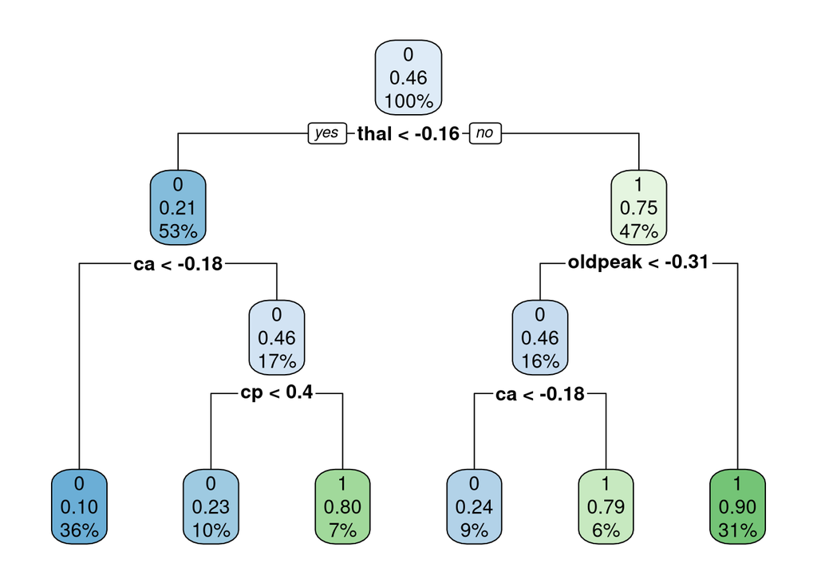

```r
# Visualize the decision tree
rpart.plot(tree_model, type = 2, extra = 106)
```

```r
# Make predictions on the test set
pred <- predict(tree_model, testData2)

pred <- prob_to_class(pred[,2])

# Confusion matrix to evaluate performance
dt_conf_mat <- confusionMatrix(reference = testData2$Class, data = pred)

# For ROC and AUC
prob <- predict(tree_model, testData2, type = "prob")[, 2]
roc_curve <- roc(testData2$Class, prob)
print(paste("AUC:", auc(roc_curve)))
```

```
## [1] "AUC: 0.819583931133429"
```

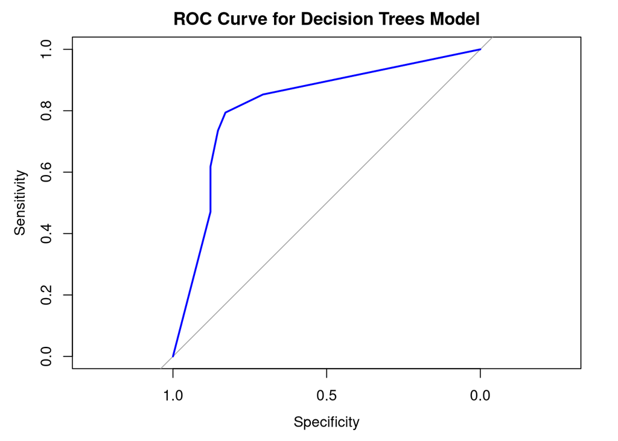

```r
# Plot the ROC curve
plot(roc_curve, col = "blue", main = "ROC Curve for Decision Trees Model")
```

## Feature Selection

To optimize feature selection, we used correlation analysis and Recursive Feature Elimination (RFE) to identify the most predictive and non-redundant features.

### Correlation Analysis with Corrplot

We generated a correlation matrix for the numeric features and visualized it with a corrplot to identify relationships among features and distinguish any highly correlated pairs.

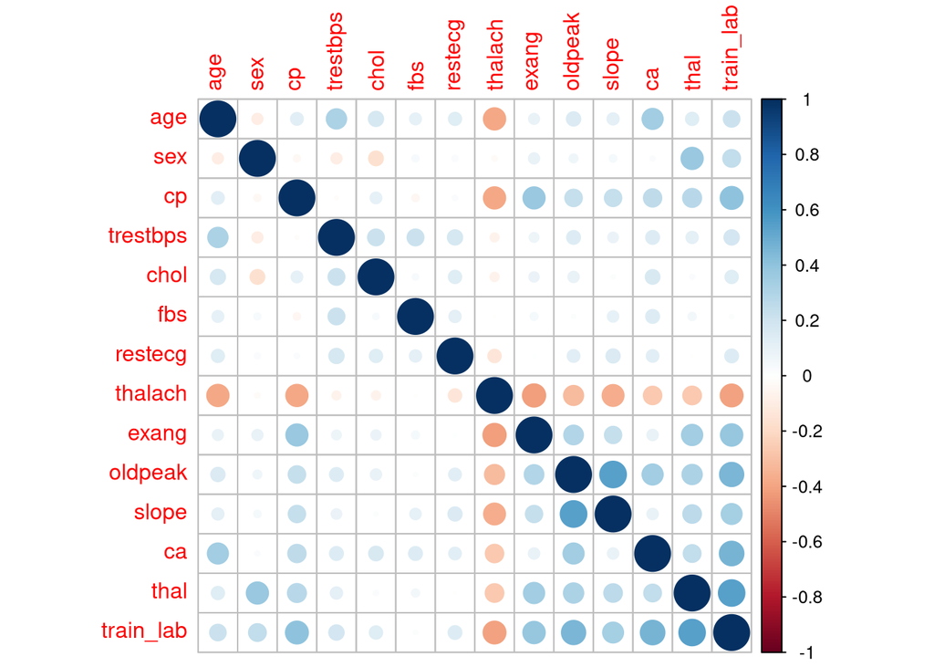

```r
# Find correlation between features and objective label
all <- cbind(train_feat,train_lab)
corrplot(cor(as.matrix(all)))
```

### Recursive Feature Elimination (RFE)

We used RFE with Random Forest to iteratively rank features by importance, testing feature subsets of sizes 3 to 7, to systematically reduce features to a core set of the most relevant ones for model accuracy.

Using cross-validation, RFE selected the smallest feature set that maintained high model performance.

```r
#Recursive Feature Elimination with Random Forest Functions and Cross Validation.

#Defined optimization parameters, using random forest as the model to optimize.
#Used cross validation as the method.
#Left additional parameters to be the default.
rfecon <- rfeControl(functions = rfFuncs,method = "cv",
                     number = 10,verbose = FALSE)

#Run RFE to find optimal features
rfe <- rfe(train_feat, train_lab,sizes = seq(3, 7, 1),
           rfeControl = rfecon)

# Optimal features
rfe_features <- rfe$optVariables

print(rfe_features)
```

```
## [1] "thal"    "ca"      "oldpeak" "cp"
```

### Summary of Feature Selection Results

```r
#Reduced data sets to only RFE selected features
train_feat_rfe <- train_feat[,rfe_features]
test_feat_rfe <- test_feat[,rfe_features]
```

## Reduced Models

### XG Boost

```r
dtrain_rfe <- xgb.DMatrix(data = train_feat_rfe, label = train_lab)
dtest_rfe <- xgb.DMatrix(data = test_feat_rfe, label = test_lab)

param <- list(
  booster = "gbtree",           # Use tree-based model
  objective = "binary:logistic",  # Specify classification objective
  eta = 0.1,                    # Learning rate
  max_depth = 3, # Maximum depth of each tree
  gamma = 1,
  subsample = 0.8,              # Subsampling ratio
  colsample_bytree = 0.8,       # Feature sampling ratio
  eval_metric = "logloss"          # Evaluation metric for classification
)

xgb_model_rfe <- xgb.train(
  params = param,
  data = dtrain_rfe,
  nrounds = 100,                    # Number of boosting rounds
  watchlist = list(train = dtrain_rfe, eval = dtest_rfe),  # Monitor training and test performance
  early_stopping_rounds = 10,       # Stop early if no improvement for 10 rounds
  print_every_n = 10                # Print progress every 10 rounds
)
```

```
## Multiple eval metrics are present. Will use eval_logloss for early stopping.
## Will train until eval_logloss hasn't improved in 10 rounds.
##
## Stopping. Best iteration:
```

```r
# Predict probabilities
pred_probs_rfe <- predict(xgb_model_rfe, dtest_rfe)

# Convert probabilities to class labels
pred_labels_rfe <- ifelse(pred_probs_rfe > 0.5, 1, 0)

# Evaluate accuracy
xgb_confusion_matrix_rfe <- confusionMatrix(reference = as.factor(test_lab),
                                    data = as.factor(pred_labels_rfe))
print(xgb_confusion_matrix_rfe)
```

```
## Confusion Matrix and Statistics
##
##           Reference
## Prediction  0  1
##          0 35  9
##          1  6 25
##
##                Accuracy : 0.8
##                  95% CI : (0.6917, 0.8835)
##     No Information Rate : 0.5467
##     P-Value [Acc > NIR] : 4.117e-06
##
##                   Kappa : 0.5934
##
##  Mcnemar's Test P-Value : 0.6056
##
##             Sensitivity : 0.8537
##             Specificity : 0.7353
##          Pos Pred Value : 0.7955
##          Neg Pred Value : 0.8065
##              Prevalence : 0.5467
##          Detection Rate : 0.4667
##    Detection Prevalence : 0.5867
##       Balanced Accuracy : 0.7945
##
##        'Positive' Class : 0
##
```

```r
# Plot feature importance
xgb_importance_matrix_rfe <- xgb.importance(model = xgb_model)
print(xgb_importance_matrix_rfe)
```

```
##      Feature       Gain       Cover  Frequency
##       <char>      <num>       <num>      <num>
##  1:     thal 0.25172816 0.184253463 0.11052632
##  2:       cp 0.15767490 0.127869980 0.10000000
##  3:  oldpeak 0.15448237 0.167654320 0.13684211
##  4:       ca 0.14263478 0.148339331 0.12105263
##  5:      age 0.08202108 0.101030032 0.14210526
##  6:     chol 0.05614602 0.073451197 0.11052632
##  7:  thalach 0.05474141 0.076847117 0.09473684
##  8: trestbps 0.03117331 0.040227324 0.06315789
##  9:    slope 0.02368516 0.028542699 0.03684211
## 10:      sex 0.02328498 0.025992611 0.04210526
## 11:    exang 0.01161468 0.008625642 0.01052632
## 12:  restecg 0.01081315 0.017166285 0.03157895
```

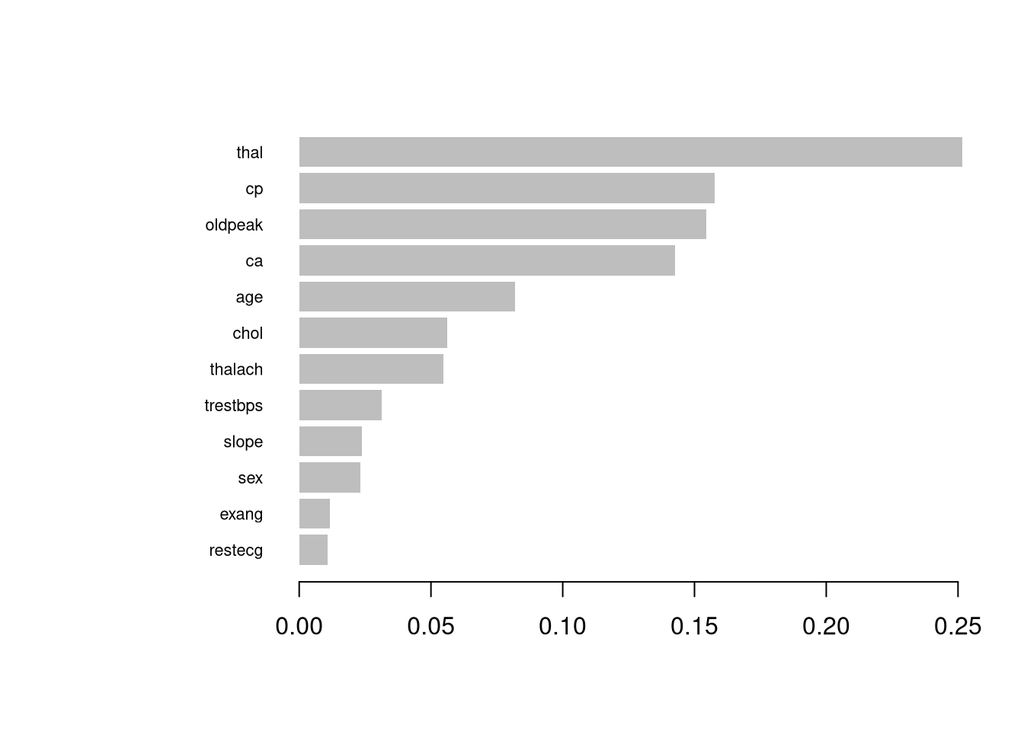

```r
# Plot the importance
xgb.plot.importance(xgb_importance_matrix_rfe)
```

```r
# AUC score
# Calculate AUC
roc_xgb_rfe <- roc(test_lab, pred_probs_rfe)  # Compute ROC curve
auc_xgb_rfe <- auc(roc_xgb_rfe)             # Calculate AUC
print(paste("AUC:", auc_xgb_rfe))
```

```
## [1] "AUC: 0.891319942611191"
```

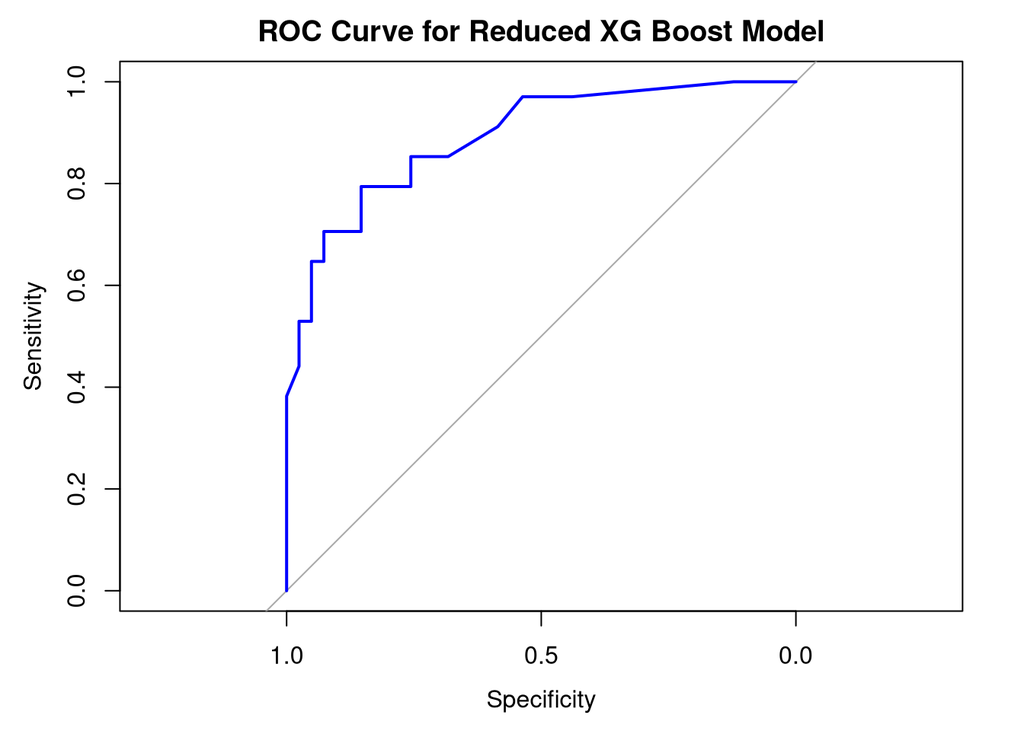

```r
# Plot the ROC curve
plot(roc_xgb_rfe, col = "blue", main = "ROC Curve for Reduced XG Boost Model")
```

### Lasso Logistic Regression

```r
#LASSO Logistic Regression using glmnet package

#Train a cross validation model to find optimal lambda value
# using cv.glmnet with alpha =1 and family = "binomial".
cv_model_rfe <- cv.glmnet(train_feat_rfe, train_lab, family = "binomial", alpha = 1)

#Extracted optimal lambda value for further tuning.
lambda_rfe <- cv_model_rfe$lambda.min

#Trained final model on all features with the optimal lambda.
lasso_rfe <- glmnet(train_feat_rfe,train_lab,family = "binomial",
                alpha = 1, lambda = lambda_rfe)

#Ranking probabilities given by Lasso on the training data.
ranking_lasso.train_rfe <- predict(lasso_rfe,train_feat_rfe, type="response")

#Ranking probabilities given by Lasso on the validation data.
ranking_lasso.test_rfe <- predict(lasso_rfe,test_feat_rfe, type="response")

#Transformed validation probability predictions to class predictions
# using 0.5 threshold
class_test.lasso_rfe <- prob_to_class(ranking_lasso.test_rfe)

#Confusion matrix for validation data.
cm_test.lasso_rfe <- confusionMatrix(reference = as.factor(test_lab),
                                 data = as.factor(class_test.lasso_rfe))

#Test prediction results
print(cm_test.lasso_rfe)
```

```
## Confusion Matrix and Statistics
##
##           Reference
## Prediction  0  1
##          0 34  6
##          1  7 28
##
##                Accuracy : 0.8267
##                  95% CI : (0.7219, 0.9043)
##     No Information Rate : 0.5467
##     P-Value [Acc > NIR] : 3.126e-07
##
##                   Kappa : 0.6512
##
##  Mcnemar's Test P-Value : 1
##
##             Sensitivity : 0.8293
##             Specificity : 0.8235
##          Pos Pred Value : 0.8500
##          Neg Pred Value : 0.8000
##              Prevalence : 0.5467
##          Detection Rate : 0.4533
##    Detection Prevalence : 0.5333
##       Balanced Accuracy : 0.8264
##
##        'Positive' Class : 0
##
```

```r
lasso_test.roc_rfe <- roc(test_lab, as.vector(ranking_lasso.test_rfe))
lasso_test.auc_rfe <- lasso_test.roc_rfe$auc

#AUC Validation Set
lasso_test.auc_rfe
```

```
## Area under the curve: 0.8673
```

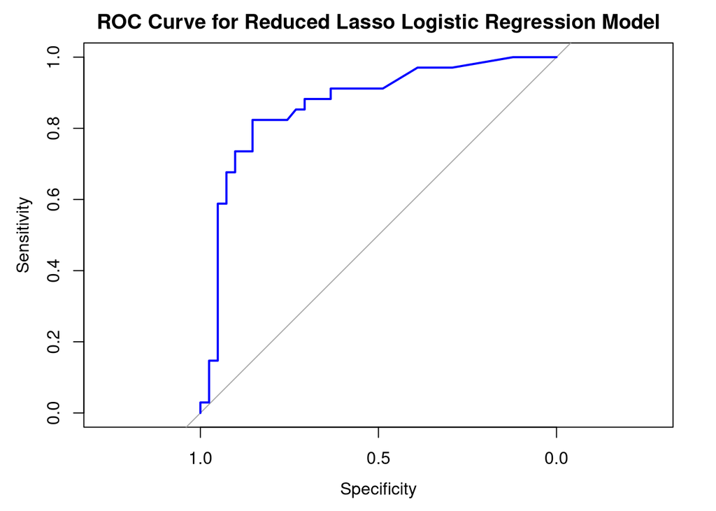

```r
# Plot the ROC curve
plot(lasso_test.roc_rfe, col = "blue",
     main = "ROC Curve for Reduced Lasso Logistic Regression Model")
```

### Random Forest

```r
# Random Forest
trainData_rfe <- data.frame(train_feat_rfe,Class = train_lab)
testData_rfe <- data.frame(test_feat_rfe,Class = test_lab)

rf_model_rfe <- randomForest(Class ~ ., data = trainData_rfe, ntree = 100, mtry = 2, importance = TRUE)
print(rf_model_rfe)
```

```
##
## Call:
##  randomForest(formula = Class ~ ., data = trainData_rfe, ntree = 100,      mtry = 2, importance = TRUE)
##                Type of random forest: regression
##                      Number of trees: 100
## No. of variables tried at each split: 2
##
##           Mean of squared residuals: 0.1327409
##                     % Var explained: 46.63
```

```r
rf_pred_rfe <- predict(rf_model_rfe, testData_rfe)

# Predict and evaluate
predictions_rfe <- prob_to_class(rf_pred_rfe)
conf_matrix_rfe <- confusionMatrix(reference = as.factor(testData_rfe$Class), data = predictions_rfe)
print(conf_matrix_rfe)
```

```
## Confusion Matrix and Statistics
##
##           Reference
## Prediction  0  1
##          0 34  9
##          1  7 25
##
##                Accuracy : 0.7867
##                  95% CI : (0.6768, 0.8729)
##     No Information Rate : 0.5467
##     P-Value [Acc > NIR] : 1.324e-05
##
##                   Kappa : 0.5674
##
##  Mcnemar's Test P-Value : 0.8026
##
##             Sensitivity : 0.8293
##             Specificity : 0.7353
##          Pos Pred Value : 0.7907
##          Neg Pred Value : 0.7812
##              Prevalence : 0.5467
##          Detection Rate : 0.4533
##    Detection Prevalence : 0.5733
##       Balanced Accuracy : 0.7823
##
##        'Positive' Class : 0
##
```

```r
# Feature importance
importance(rf_model_rfe)
```

```
##           %IncMSE IncNodePurity
## thal    16.868174     11.086233
## ca      16.074332      8.258475
## oldpeak 11.359691     13.535151
## cp       9.722337      9.490454
```

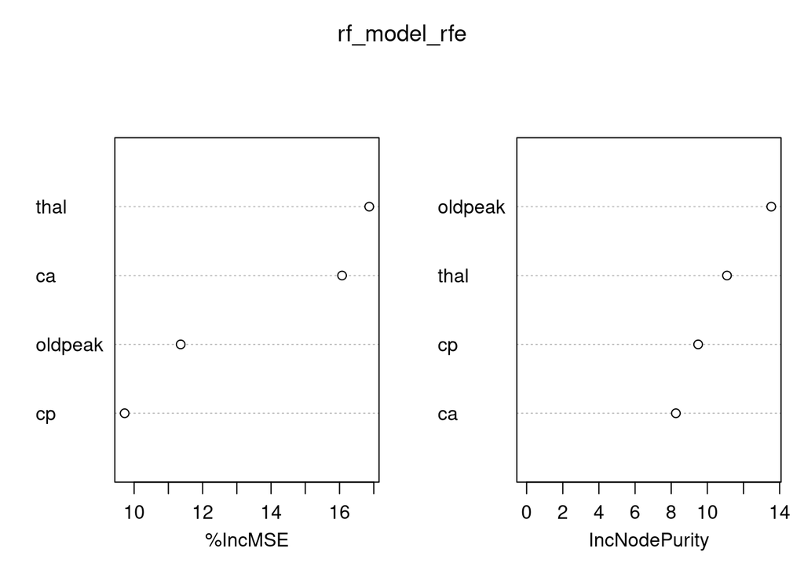

```r
varImpPlot(rf_model_rfe)
```

```r
# Calculate AUC
rf_roc_rfe <- roc(testData$Class, rf_pred_rfe)  # Compute ROC curve
rf_auc_rfe <- auc(rf_roc_rfe)                   # Calculate AUC
print(paste("AUC:", rf_auc_rfe))
```

```
## [1] "AUC: 0.88558106169297"
```

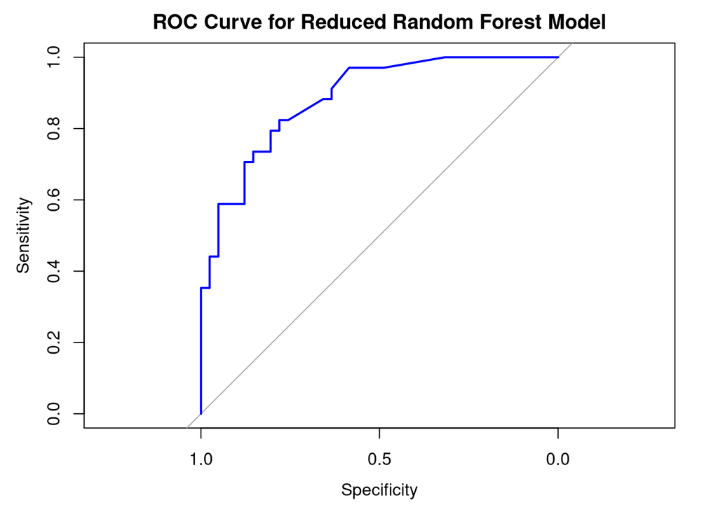

```r
# Plot the ROC curve
plot(rf_roc_rfe, col = "blue", main = "ROC Curve for Reduced Random Forest Model")
```

### Decision Trees

```r
# Data preparation
trainData2_rfe <- trainData_rfe
testData2_rfe <- testData_rfe
trainData2_rfe$Class <- as.factor(trainData2_rfe$Class)
testData2_rfe$Class <- as.factor(testData2_rfe$Class)
# Train the decision tree model
tree_model_rfe <- rpart(
  Class ~ .,          # Formula: predicting Class using all other variables
  data = trainData2_rfe,  # Training data
  method = "class",   # Method "class" for classification trees
  control = rpart.control(minsplit = 20, cp = 0.01)  # Control parameters
)

# Print the model summary
print(tree_model_rfe)
```

```
## n= 222
##
## node), split, n, loss, yval, (yprob)
##       * denotes terminal node
##
##  1) root 222 103 0 (0.53603604 0.46396396)
##    2) thal< -0.1615968 118  25 0 (0.78813559 0.21186441)
##      4) ca< -0.184126 81   8 0 (0.90123457 0.09876543) *
##      5) ca>=-0.184126 37  17 0 (0.54054054 0.45945946)
##       10) cp< 0.4001594 22   5 0 (0.77272727 0.22727273) *
##       11) cp>=0.4001594 15   3 1 (0.20000000 0.80000000) *
##    3) thal>=-0.1615968 104  26 1 (0.25000000 0.75000000)
##      6) oldpeak< -0.3120299 35  16 0 (0.54285714 0.45714286)
##       12) ca< -0.184126 21   5 0 (0.76190476 0.23809524) *
##       13) ca>=-0.184126 14   3 1 (0.21428571 0.78571429) *
##      7) oldpeak>=-0.3120299 69   7 1 (0.10144928 0.89855072) *
```

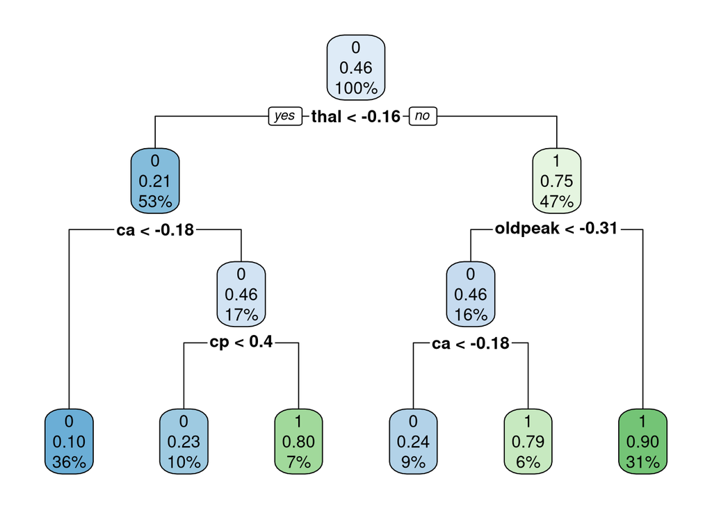

```r
# Visualize the decision tree
rpart.plot(tree_model_rfe, type = 2, extra = 106)
```

```r
# Make predictions on the test set
pred_rfe <- predict(tree_model_rfe, testData2_rfe)

pred_rfe <- prob_to_class(pred_rfe[,2])

# Confusion matrix to evaluate performance
dt_conf_mat_rfe <- confusionMatrix(reference = testData2_rfe$Class, data = pred_rfe)
print(dt_conf_mat_rfe)
```

```
## Confusion Matrix and Statistics
##
##           Reference
## Prediction  0  1
##          0 35  9
##          1  6 25
##
##                Accuracy : 0.8
##                  95% CI : (0.6917, 0.8835)
##     No Information Rate : 0.5467
##     P-Value [Acc > NIR] : 4.117e-06
##
##                   Kappa : 0.5934
##
##  Mcnemar's Test P-Value : 0.6056
##
##             Sensitivity : 0.8537
##             Specificity : 0.7353
##          Pos Pred Value : 0.7955
##          Neg Pred Value : 0.8065
##              Prevalence : 0.5467
##          Detection Rate : 0.4667
##    Detection Prevalence : 0.5867
##       Balanced Accuracy : 0.7945
##
##        'Positive' Class : 0
##
```

```r
# For ROC and AUC
prob_rfe <- predict(tree_model_rfe, testData2_rfe, type = "prob")[, 2]
roc_curve_rfe <- roc(testData2_rfe$Class, prob_rfe)
print(paste("AUC:", auc(roc_curve_rfe)))
```

```
## [1] "AUC: 0.819583931133429"
```

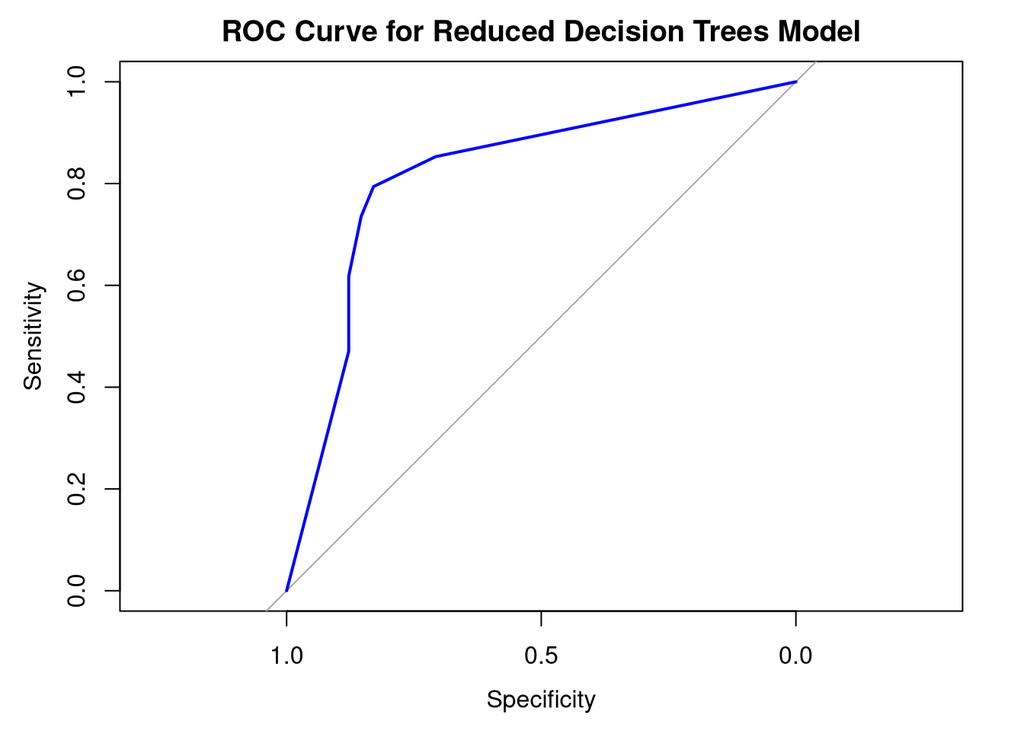

```r
# Plot the ROC curve
plot(roc_curve_rfe, col = "blue", main = "ROC Curve for Reduced Decision Trees Model")
```

## Results Summary

```r
# Comparison Table
comparison <- rbind(confusion_matrix$byClass,
                    cm_test.lasso$byClass,
                    conf_matrix$byClass,
                    dt_conf_mat$byClass,
                    xgb_confusion_matrix_rfe$byClass,
                    cm_test.lasso_rfe$byClass,
                    conf_matrix_rfe$byClass,
                    dt_conf_mat_rfe$byClass)

colnames(comparison) <- c("Sensitivity",    "Specificity",
                          "Pos Pred Value", "Neg Pred Value",   "Precision",
                          "Recall", "F1",   "Prevalence",   "Detection Rate",
                          "Detection Prevalence",   "Balanced Accuracy")

comparison <- cbind(Model = c("XG Boost", "Lasso Logistic Regression",
                              "Random Forest", "Decision Trees",
                              "XG Boost - Reduced Features",
                              "Lasso LR - Reduced Features",
                              "Random Forest - Reduced Features",
                              "Decision Trees - Reduced Features"), comparison)

# Create an HTML table with column-based comparisons for maximum and minimum values, ignoring the first column
html_table <- as.data.frame(comparison) %>%
  mutate(across(-Model, ~ cell_spec(
    ., format = "html",
    bold = . == max(., na.rm = TRUE) | . == min(., na.rm = TRUE),  # Bold for max/min values in each column, ignoring the first
    color = ifelse(. == max(., na.rm = TRUE) | . == min(., na.rm = TRUE),
                   "white", "black"),  # Text color
    background = case_when(
      . == max(., na.rm = TRUE) ~ "green",  # Green background for column max values
      . == min(., na.rm = TRUE) ~ "red",    # Red background for column min values
      TRUE ~ "transparent"                  # No background for other values
    )
  ))) %>%
  kable(escape = FALSE, format = "html") %>%  # Create HTML table
  kable_styling() %>%  # Apply styling to the table
  add_header_above(c(" " = 1,
                     "Table 1: Difference of Performance across different models" = 11))


html_table
```

| Model | Table 1: Difference of Performance across different models Sensitivity | Table 1: Difference of Performance across different models Specificity | Table 1: Difference of Performance across different models Pos Pred Value | Table 1: Difference of Performance across different models Neg Pred Value | Table 1: Difference of Performance across different models Precision | Table 1: Difference of Performance across different models Recall | Table 1: Difference of Performance across different models F1 | Table 1: Difference of Performance across different models Prevalence | Table 1: Difference of Performance across different models Detection Rate | Table 1: Difference of Performance across different models Detection Prevalence | Table 1: Difference of Performance across different models Balanced Accuracy |
| --- | --- | --- | --- | --- | --- | --- | --- | --- | --- | --- | --- |
| XG Boost | 0.878048780487805 | 0.764705882352941 | 0.818181818181818 | 0.838709677419355 | 0.818181818181818 | 0.878048780487805 | 0.847058823529412 | 0.546666666666667 | 0.48 | 0.586666666666667 | 0.821377331420373 |
| Lasso Logistic Regression | 0.853658536585366 | 0.794117647058823 | 0.833333333333333 | 0.818181818181818 | 0.833333333333333 | 0.853658536585366 | 0.843373493975904 | 0.546666666666667 | 0.466666666666667 | 0.56 | 0.823888091822095 |
| Random Forest | 0.853658536585366 | 0.735294117647059 | 0.795454545454546 | 0.806451612903226 | 0.795454545454545 | 0.853658536585366 | 0.823529411764706 | 0.546666666666667 | 0.466666666666667 | 0.586666666666667 | 0.794476327116212 |
| Decision Trees | 0.853658536585366 | 0.735294117647059 | 0.795454545454546 | 0.806451612903226 | 0.795454545454545 | 0.853658536585366 | 0.823529411764706 | 0.546666666666667 | 0.466666666666667 | 0.586666666666667 | 0.794476327116212 |
| XG Boost - Reduced Features | 0.853658536585366 | 0.735294117647059 | 0.795454545454546 | 0.806451612903226 | 0.795454545454545 | 0.853658536585366 | 0.823529411764706 | 0.546666666666667 | 0.466666666666667 | 0.586666666666667 | 0.794476327116212 |
| Lasso LR - Reduced Features | 0.829268292682927 | 0.823529411764706 | 0.85 | 0.8 | 0.85 | 0.829268292682927 | 0.839506172839506 | 0.546666666666667 | 0.453333333333333 | 0.533333333333333 | 0.826398852223816 |
| Random Forest - Reduced Features | 0.829268292682927 | 0.735294117647059 | 0.790697674418605 | 0.78125 | 0.790697674418605 | 0.829268292682927 | 0.80952380952381 | 0.546666666666667 | 0.453333333333333 | 0.573333333333333 | 0.782281205164993 |
| Decision Trees - Reduced Features | 0.853658536585366 | 0.735294117647059 | 0.795454545454546 | 0.806451612903226 | 0.795454545454545 | 0.853658536585366 | 0.823529411764706 | 0.546666666666667 | 0.466666666666667 | 0.586666666666667 | 0.794476327116212 |

```r
html_file <- tempfile(fileext = ".html")
save_kable(html_table, "results_ads.html")
```

### Model Comparisons

From the results file, each model’s performance metrics were compared on two sets of features: the full dataset and the reduced feature set selected through Recursive Feature Elimination (RFE).

XGBoost:

With the full feature set, XGBoost performed well, showing high sensitivity and specificity, with a notable AUC score. On the reduced feature set, XGBoost maintained similar performance levels, indicating that the selected features captured the most relevant patterns without adding noise.

Lasso Logistic Regression:

Random Forest:

Decision Trees: